# EDLD 651 Final Paper

Author

Febe Lin, Ramtin Ranjpour, & James Phillips

## Abstract

This study examines the relationship between social media usage, sleep duration, digital platform selection, and mental health among a sample of students from various global regions. The study tested a mediation hypothesis that sleep deprivation mediates the negative relationship between daily screen usage and mental health scores. Our results support a partial mediation model, indicating that while sleep duration plays a role, it does not fully account for the effect of screen usage on mental health. We further explored the “tipping point” of screen usage, finding that the negative trend is stepwise; this suggests there is no comparatively “safe zone” for screen usage. Additionally, the pattern differs by gender, impacting female students more significantly than male students. Findings also suggested that there are significant differences between primary digital platform usage and reported mental health scores. Finally, students in the Far East tended to report better mental health and fewer social media conflicts than those in the Middle East, with students in the United States (US) reporting the most conflict. Across all regions, poorer mental health was linked to greater social media conflict, and this link was noticeably stronger outside the United States.

## Introduction

*Screen Time, Sleep, and Mental Health*

The existing literature shows that daily screen time of two hours or more is consistently associated with lower psychological well-being, including higher depressive and anxiety symptoms, poorer environmental mastery, and reduced personal growth (Twenge and Campbell 2018; Basterra-Gortari et al. 2024; Alvarez de Mon et al. 2024; Stiglic and Viner 2019). At the same time, studies point out that moderate use does not appear harmful and that benefits emerge when screen time is replaced with physical activity, although some scholars warn that effects depend on the context and the type of digital activity (Twenge and Campbell 2018; Basterra-Gortari et al. 2024; Pontes 2021). Previous research identifies sleep as a key mediating pathway, with reviews showing that device use disrupts sleep through time displacement, psychological stimulation, and circadian rhythm interference, as these sleep disturbances consistently predict poorer mental health outcomes (Dibben et al. 2023; Hale 2019). Evidence across numerous studies further showcases that poor sleep quality is strongly linked to higher depression and anxiety, though scholars note that experimental work is required to clarify the exact causal pathways (Alonzo et al. 2021; LeBourgeois et al. 2017). Furthermore, the evidence for tipping-point effects is modest; however, it suggests that while moderate use of social media may be harmless, escalating or prolonged engagement leads to sharper declines in sleep and mental health, as demonstrated in quadratic well-being patterns (Przybylski and Weinstein 2017) and worsening sleep and psychological outcomes with dysfunctional use (Pagano, Bacaro, and Crocetti 2023). Prior studies have also modeled sleep as a mediating pathway using techniques such as multilevel mediation and structural equation modeling to consistently demonstrate that technology use worsens sleep quality, which in turn predicts poorer mental health outcomes as well (Ahmed et al. 2025; Shadzi, Salehi, and Vardanjani 2020; Alonzo et al. 2021).

*Platform Effects, Addiction, and Cross-Regional Differences*

The current scholarship tells us that platforms differ markedly in their psychological impacts, with evidence that Snapchat and YouTube users report higher anxiety and stress, while Facebook users report lower anxiety, and that using a larger number of platforms predicts substantially higher risks of both depression and anxiety (Merino et al. 2025; Primack et al. 2017). Simultaneously, platform effects are not uniform, since studies have found that Instagram and Snapchat users show comparatively higher well-being, emphasizing that different social environments and content cultures shape mental health outcomes in unique ways (Di Cara et al. 2022). Studies consistently link visually driven platforms to greater harm, including higher anxiety, stress, and mood decline as their image-centric environments intensify appearance-based social comparisons and lower body satisfaction (Merino et al. 2025; Engeln et al. 2020; Kohler, Turner, and Webster 2021). Such effects specific to these platforms are primarily explained by upward social comparison and passive content consumption, which amplify emotional distress and interact with individual vulnerabilities to shape negative psychological outcomes (Aubry, Quiamzade, and Meier 2024; Verduyn et al. 2020). On the same vein, studies point out that apps like TikTok, Tumblr, and Instagram are the ones most strongly linked to addictive or impulsive behaviors, with TikTok identified as the most addictive during the COVID-19 pandemic, alongside Tumblr and TikTok showing the highest addiction correlations overall (Montag et al. 2024; Marengo et al. 2022). Once more, image-centric platforms predict higher addiction scores, which align with findings that the users of these platforms report elevated problematic use in comparison to users of others (Côrte-Real et al. 2023; Kircaburun et al. 2020). In terms of regions, students from the Middle East and the Far East express distress more collectively and with fewer clinical terms than US students, which often involves invoking national identity and showing stronger in-group support on online platforms (Pendse, Niederhoffer, and Sharma 2019; Al-Krenawi et al. 2009). US students tend to display more direct negative expression and online conflict, whereas Eastern students’ more collectivist norms shape a more restrained online behavior and different patterns of stress and support-seeking (Lake 2011; Smith, Görzig, and Robinson 2019).

*Where Our Research Comes in*

The pervasive integration of social media platforms into the daily lives of students has raised significant concerns regarding its impact on academic performance, psychological health, and interpersonal relationships(Barthorpe et al. 2020; Neophytou, Manwell, and Eikelboom 2021; Naslund et al. 2020). This study aims to empirically test these relationships among social media habits, sleeping duration, digital platform selection and self-reported mental health, by using a dataset from Kaggle(Shamim 2025).

The first research question asks whether sleep deprivation acts as a mediator between screen time and mental health ($RQ_1$). We hypothesized that increased screen time would negatively predict sleep duration, which in turn would degrade mental health scores ($H_1$).

Additionally, we sought to identify a “tipping point” of screen usage where mental health significantly declines ($RQ_2$). We divide students into three groups: minimal (0–3 hours), moderate (3–5 hours), and maximal usage (more than 5 hours). Our hypothesis was that mental health scores would change smoothly between the minimal and moderate groups, but drop drastically for the maximal group ($H_2$). We also hypothesized that these effects might differ across genders ($H_3$).

Our focus next shifted toward potential correlates with specific platform prioritization. In this, we explored how individual platform use was linked to mental health ($RQ_3$), with particular attention paid to lower mental health ratings ($RQ_4$), as well as the hypothesized link of Meta-affiliated platforms (Facebook, Instagram, and WhatsApp) to lower mental health scores ($H_4$). Specific platform usage and its correlation to social media addiction were also examined ($RQ_5$), with Meta-affiliated platforms once again hypothesized to be related, in this case being linked to higher levels of addiction ($H_5$).

Finally, ($RQ_6$) uses a geographical lens to compare college students in the US to students in the Middle East and the Far East to discover the differences in how mental health affects conflicts over social media.

## Methods

For our first research question, we used three distinct linear regression models, testing the influence of screen time (IV) on sleep (Mediator), the total effect on mental health (DV), and the combined influence of the IV and the mediator on the DV. This path analysis allowed us to build a mediation model step-by-step and assess the mediation effect.

For the second research question, we utilized one-way ANOVA tests on three groups. Separate ANOVA tests were calculated for male and female students, and Tukey HSD post-hoc tests were used following analysis.

For research questions three and five, to compare mental health outcomes and social media addiction scores across different platforms, we computed aggregate statistics (mean and SD) for each platform. As for our fourth research question, we first categorized mental health scores into ‘low’ and ‘not low’ groups based on the sample mean. Subsequently, a Pearson’s Chi-square test of independence was utilized to validate that the differences observed across digital platforms were statistically significant and not merely due to random chance.

Finally, for our sixth research question, we employed a multiple linear regression model with an interaction term to examine how the relationship between mental health and social media conflict varies by geographic region (USA, Middle East, and Far East). This interaction analysis was supplemented by region-specific Pearson correlation coefficients to quantify the distinct strength of the association within each cultural context.

In using R, this data work was made possible thanks to the following resource packages: {rio} (Chan et al. 2023), {here} (Müller 2020), {tidyverse} (Wickham et al. 2019), {tidylog} (Elbers 2024), {janitor} (Firke 2023), {skimr} (Waring et al. 2022), {knitr} (Xie 2014, 2023, 2015), and {kableExtra} (Zhu 2024).

## Results

### Sleep

*RQ*<sub>**1**</sub>**: Does sleep deprivation mediate the negative relationship between daily screen time and mental health scores?**

- *H*<sub>**1**</sub>**: Screen time negatively predicts sleep time, which in turn negatively impacts mental health.**

The regression analysis results support the hypothesis that sleep duration partially mediates the relationship between screen time and mental health. First, we plotted the data to demonstrate the negative association between screen time and mental health (Figure 1), as well as screen time and sleep duration (Figure 2). Subsequently, we conducted three linear regression models to test our hypothesis. To better visualize these structural relationships, we generated a path analysis diagram (Figure 3) based on the models’ results.

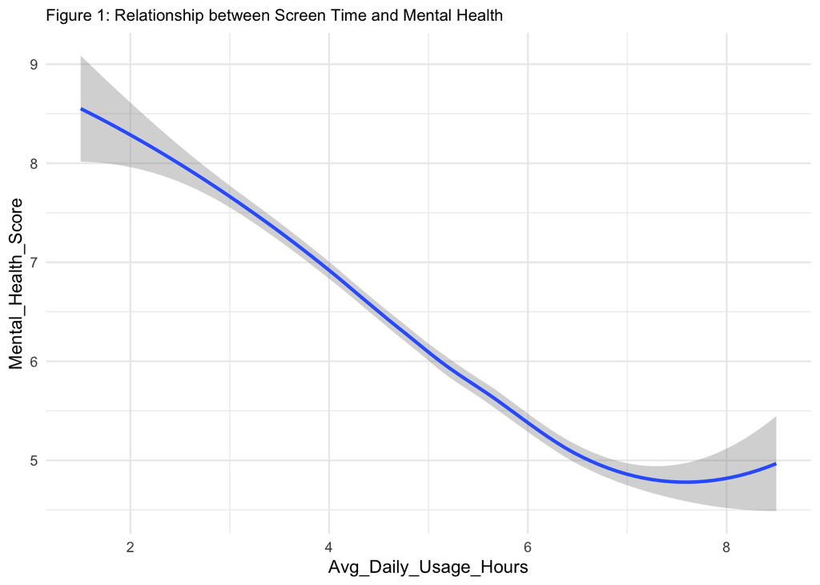

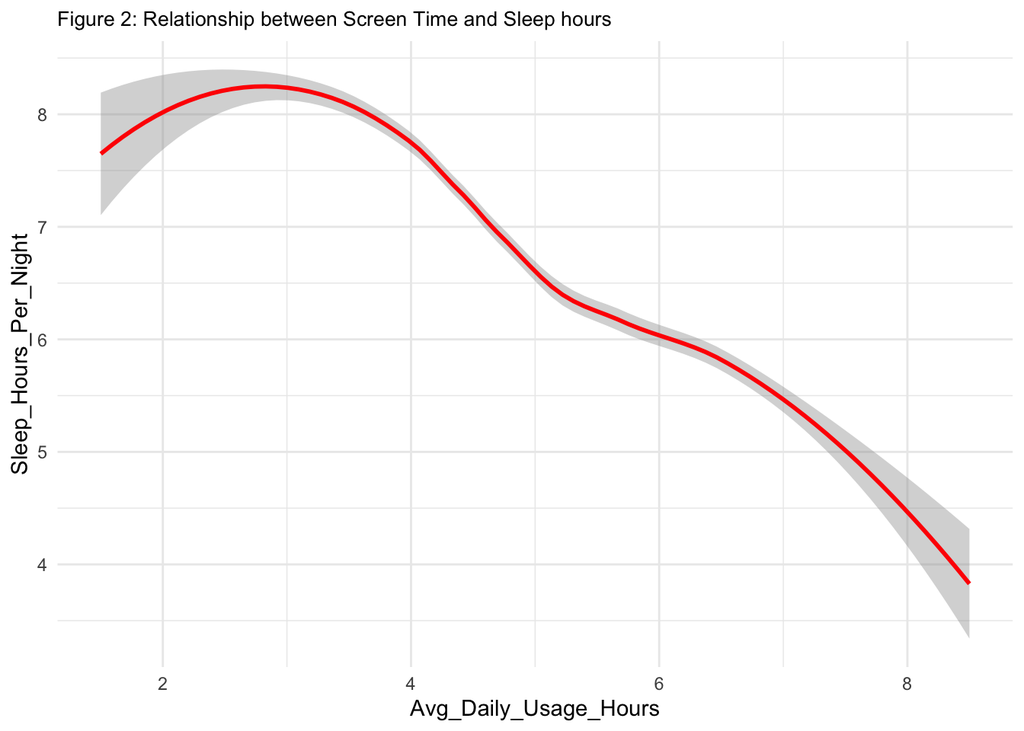

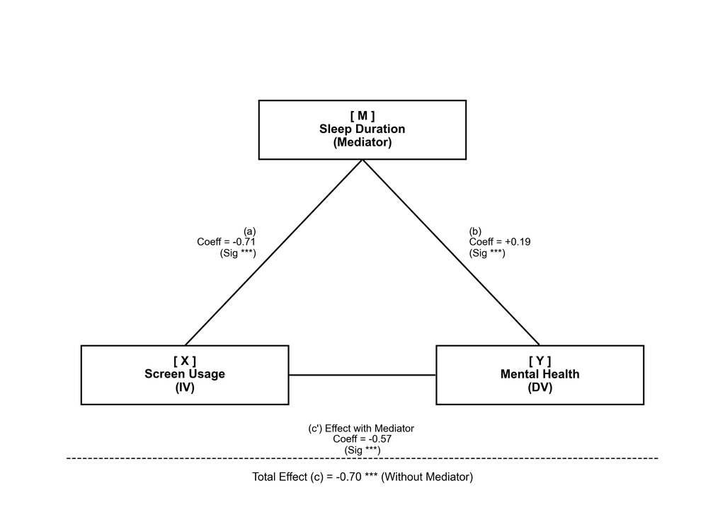

Figure 3

First, Model A showed that screen usage also significantly negatively predicted sleep duration (b = -0.71, p<0.001, $R^2$ = 0.63), confirming the path from the independent variable to the mediator.

Second, Model C revealed a significant total effect, where daily screen usage negatively predicted mental health scores (b = -0.7, p<0.001, $R^2$ = 0.64 ).

Finally, in Model C’, when both screen usage and sleep duration were included, sleep duration was positively associated with mental health. Screen time continued to negatively predict mental health even after controlling for sleep duration (b = -0.57, p<0.001, $R^2$ = 0.66). Notably, while the direct effect of screen usage on mental health remained significant, the coefficient decreased from -0.70 to -0.57.

This reduction in the coefficient suggests that sleep duration partially mediates the negative impact of screen time on mental health.

*RQ*<sub>**2**</sub>**: Is there a critical ‘tipping point’ in screen usage where sleep duration and mental health exhibit a sharp decline?**

- *H*<sub>**2**</sub>**: Students exceeding a threshold of 5 hours per day will report significantly worse outcomes compared to low-usage groups, whereas the difference between low (0~3) and moderate usage (3~5)may be minimal.**
- *H*<sub>**3**</sub>**: However, this pattern may vary by gender, and the differences in outcomes may not be the same across male and female students.**

As we mentioned before, three groups were divided by their screen use time, and the figure 4 does show a negative effect of daily screen time on mental health, but there is no clear “tipping point.” Instead, the decline appears more stepwise, with mental health decreasing gradually across each usage group, which means $H_2$ was not supported.

The most interesting finding is that the downward trend is evident for both genders, but the decline is notably steeper among female students, especially in the high-usage category, suggesting that excessive screen exposure may have a stronger negative impact on females’ psychological well-being.

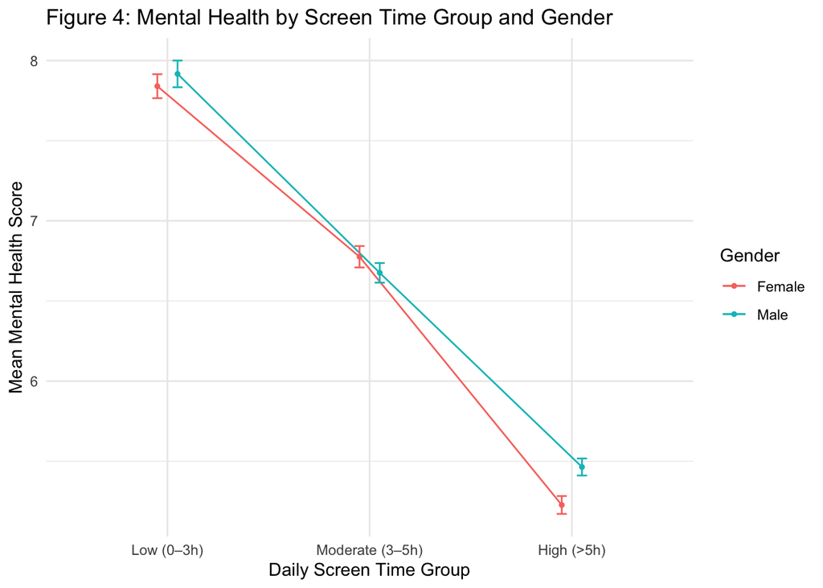

To statistically verify the patterns observed in the plot, we conducted separate one-way ANOVAs for male and female students. Also, we conducted Tukey HSD post-hoc analysis. The results show that significant declines across all usage levels for both male(all ps <.001) and female(all ps <.001). For male students, mental health scores dropped by 1.24 points from the Low to Moderate group, and by another 1.21 points from the Moderate to High group.

In contrast, female students showed an accelerating decline. While the drop from Low to Moderate usage was 1.06 points, the decline became much steeper, dropping by 1.55 points, when moving from Moderate to High usage. This indicates that excessive screen time (>5h) may have a more severe marginal impact on female students. Therefore, $H_3$ was supported.

### Platform Use

*RQ*<sub>**3**</sub>**: How does primary usage of a specific social media platform impact mental health?**

- *H*<sub>**4**</sub>**: Prioritized use of Meta-affiliated platforms, such as Facebook, Instagram, and WhatsApp, will result in a greater negative impact to mental health compared to other platforms.**

To first understand the relationship between respondents indicating a specific platform as their most-used and reported mental health, data was associated between platform use and average mental health, as modeled below.

Mean Mental Health Scores by Platform

| Most Used Platform | n | Mean | Standard Deviation |
| --- | --- | --- | --- |
| LINE | 12 | 8.00 | 0.00 |
| LinkedIn | 21 | 8.00 | 0.32 |
| VKontakte | 12 | 7.00 | 0.00 |
| Twitter | 30 | 6.83 | 1.05 |
| Facebook | 123 | 6.72 | 1.03 |
| YouTube | 10 | 6.60 | 0.70 |
| WeChat | 15 | 6.47 | 0.52 |
| Instagram | 249 | 6.12 | 1.17 |
| KakaoTalk | 12 | 6.00 | 0.00 |
| TikTok | 154 | 5.71 | 0.80 |
| Snapchat | 13 | 5.54 | 0.78 |
| WhatsApp | 54 | 5.54 | 0.50 |

Our results varied when testing the affiliated hypothesis: while Facebook and Instagram did not link to lower reported mental health statuses (*M<sub>F</sub>* = 6.72, *SD<sub>F</sub>* = 1.03; *M<sub>I</sub>* = 6.12, *SD<sub>I</sub>* = 1.17), users who reported WhatsApp as their most-used digital platform exhibited the lowest mental health scores of all respondents (*M* = 5.54, *SD* = 0.503). As such, $H_4$ was only partially supported.

*RQ*<sub>**4**</sub>**: Do any specific social media platforms significantly correlate to lower self-reported mental health statuses?**

Our focus next looked at possibly significant correlations between specific platform prioritization and what we deemed as “low mental heath.” From our data, “low mental health” was characterized as any respondents whose mean mental health score was returned as being lower than the cumulative average mental health score from all respondents. This then grouped respondents into either a “low” or a “not low” group, represented below based on percentage of respondents, to see if any specific platform had a significantly larger population of “low” respondents compared to those who were “not low.”

Percentages of Lower Than Average Mental Health Reports by Platform

| Most Used Platform | Low (%) | Not Low (%) |
| --- | --- | --- |
| KakaoTalk | 100.0 | 0.0 |
| WhatsApp | 100.0 | 0.0 |
| Snapchat | 92.3 | 7.7 |
| TikTok | 86.4 | 13.6 |
| Instagram | 61.8 | 38.2 |
| WeChat | 53.3 | 46.7 |
| Twitter | 36.7 | 63.3 |
| YouTube | 30.0 | 70.0 |
| Facebook | 27.6 | 72.4 |
| LINE | 0.0 | 100.0 |
| LinkedIn | 0.0 | 100.0 |
| VKontakte | 0.0 | 100.0 |

Based on these findings, the majority of those who primarily use Instagram, KakaoTalk, Snapchat, TikTok, WeChat, and WhatsApp have lower-than-average reported mental health. As well, $H_4$ continued to be partially supported, with both WhatsApp (100%) and Instagram (61.8%) having the majority of their grouped respondents also reporting lower then average mental health, while Facebook (27.6%) did not have its majority in the lower group.

Using a chi-square test of independence, we sought to measure if these differences reflect a statistically significant relationship. Our results indicated a significant association between primary platform use and reported mental health status (χ² = 226.05, *df* = 11, *p* < .001), suggesting that low versus not-low mental health frequencies vary across platforms to a noteworthy degree.

*RQ*<sub>**5**</sub>**: Do any specific platforms correlate to higher levels of social media addiction?**

- *H*<sub>**5**</sub>**: Prioritized use of Meta-affiliated platforms, such as Facebook, Instagram, and WhatsApp, will result in higher levels of social media addiction compared to other platforms.**

For the last research question and associated hypothesis pertaining to platform usage, we examined reported levels of addiction to social media in general based on the platform most used by the respondent in an attempt to determine if prioritized usage of any specific platform was linked to higher levels of addiction. These results were reported as means based on each group, displayed below.

Social Media Addiction by Platform

| Most Used Platform | n | Mean | Standard Deviation |
| --- | --- | --- | --- |
| WhatsApp | 54 | 7.46 | 0.50 |
| Snapchat | 13 | 7.46 | 0.78 |
| TikTok | 154 | 7.43 | 1.04 |
| Instagram | 249 | 6.55 | 1.54 |
| YouTube | 10 | 6.10 | 1.37 |
| WeChat | 15 | 6.07 | 1.03 |
| KakaoTalk | 12 | 6.00 | 0.00 |
| Facebook | 123 | 5.67 | 1.44 |
| Twitter | 30 | 5.50 | 1.55 |
| VKontakte | 12 | 5.00 | 0.00 |
| LinkedIn | 21 | 3.81 | 0.60 |
| LINE | 12 | 3.00 | 0.00 |

The resulting data indicated that those who reported using WhatsApp or Snapchat the most also reported the highest level of addiction to social media (*M<sub>WA</sub>* = 7.46, *SD* = 0.5; *M<sub>S</sub>* = 7.46, *SD* = 0.78), closely followed by those who reported TikTok as their most used platform (*M* = 7.43, *SD* = 1.04). Those who reported using LINE as their most used platform reported the lowest level of addiction to social media (*M* = 3, *SD* = 0).

Similar to $H_4$, $H_5$ was partially supported by these findings, with WhatsApp’s prioritized usage having the highest level of reported social media addiction and Instagram not far behind; Facebook, in contrast, reported a near-average level of social media addiction (*M* = 5.67, *SD* = 1.44).

### Regions

For the last research question, we wanted to use a geographical lens to compare the United States with two regions in Asia to discover the differences in how mental health affects conflicts over social media.

*RQ*<sub>**6**</sub>**: Among college students, comparing students from the United States to those from the Middle East and the Far East, how does mental health affect conflicts over social media?**

For this question, we filtered the responses into three groups by country: the United States, the Middle East, and the Far East, with each group representing one of the three authors. We also exclusively looked at college students, both undergraduate- and graduate-level, thereby removing high school-age students to remain representative of the authors once again.

Data summary

| Name | students |
| --- | --- |
| Number of rows | 150 |
| Number of columns | 7 |
| _______________________ |  |
| Column type frequency: |  |
| character | 3 |
| numeric | 4 |
| ________________________ |  |
| Group variables | None |

**Variable type: character**

| skim_variable | n_missing | complete_rate | min | max | empty | n_unique | whitespace |
| --- | --- | --- | --- | --- | --- | --- | --- |
| region | 0 | 1 | 3 | 11 | 0 | 3 | 0 |
| academic_level | 0 | 1 | 8 | 13 | 0 | 2 | 0 |
| gender | 0 | 1 | 4 | 6 | 0 | 2 | 0 |

**Variable type: numeric**

| skim_variable | n_missing | complete_rate | mean | sd | p0 | p25 | p50 | p75 | p100 | hist |
| --- | --- | --- | --- | --- | --- | --- | --- | --- | --- | --- |
| student_id | 0 | 1 | 407.60 | 187.58 | 3 | 275.5 | 426.5 | 555.75 | 704 | ▃▅▆▇▇ |
| age | 0 | 1 | 20.48 | 1.44 | 19 | 19.0 | 20.0 | 21.00 | 24 | ▇▂▂▁▁ |
| mental_health_score | 0 | 1 | 5.98 | 1.13 | 4 | 5.0 | 6.0 | 6.00 | 8 | ▂▅▇▁▃ |
| conflicts_over_social_media | 0 | 1 | 2.97 | 0.99 | 0 | 3.0 | 3.0 | 4.00 | 4 | ▁▂▂▇▆ |

Next, we ran inferential tests with mental health as the independent variable, region as the grouping, and conflicts over social media as the dependent variable.

Correlation Between Mental Health and Social Media Conflicts by Region

| region | n | r_mh_conflict |
| --- | --- | --- |
| Far East | 69 | -0.902 |
| Middle East | 41 | -0.983 |
| USA | 40 | -0.786 |

With a multiple regression model that included centered mental health scores, three regions, and their interaction, the descriptive statistics showed that students from the Far East reported the highest mental health scores (*M* = 6.77, *SD* = 0.91) and the lowest social media conflict levels (*M* = 2.30, *SD* = 0.86), followed by students from the Middle East next (*M<sub>MH</sub>* = 5.71, *SD* = 0.75; *M<sub>C</sub>* = 3.27, *SD* = 0.81, respectively) and the United States last (*M<sub>MH</sub>* = 4.90, *SD* = 0.71; *M<sub>C</sub>* = 3.80, *SD* = 0.41). Mental health was strongly and negatively associated with social media conflict across the board, and the relationship varied by the region, with the strongest correlations observed in the Middle East (*r* = −.98), followed by the Far East (*r* = −.90) and the United States (*r* = −.79). It was also revealed that the strength of this association was significantly different across regions, which suggest that poorer mental health predicts higher levels of conflict over social media more strongly in the Middle East and the Far East in comparison to students in the US.

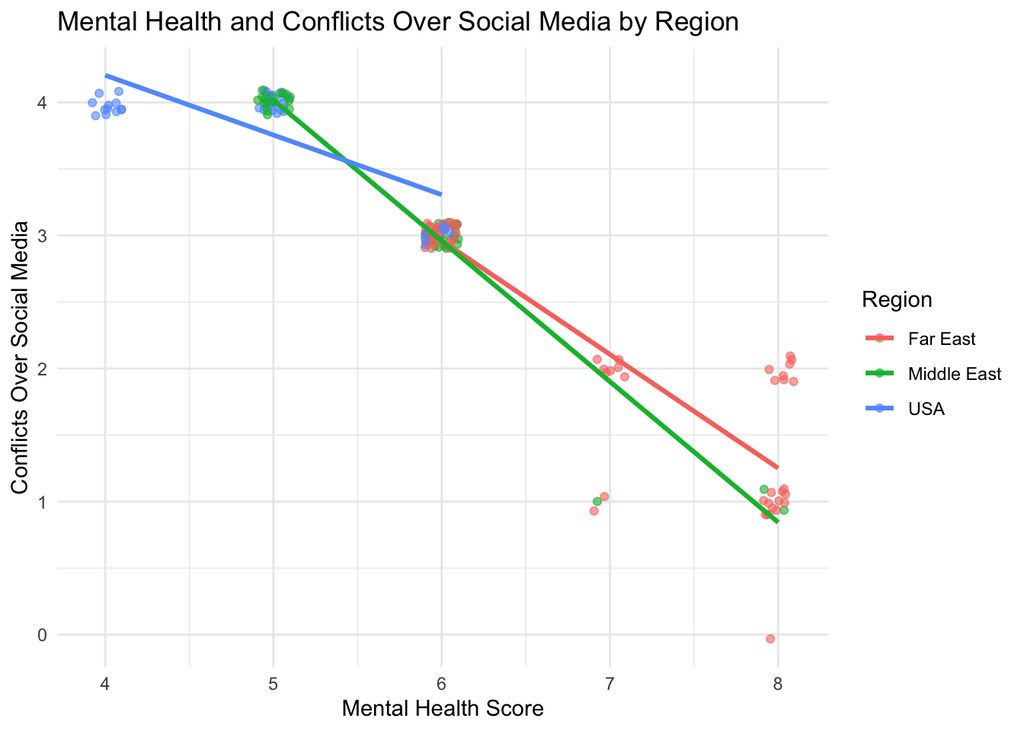

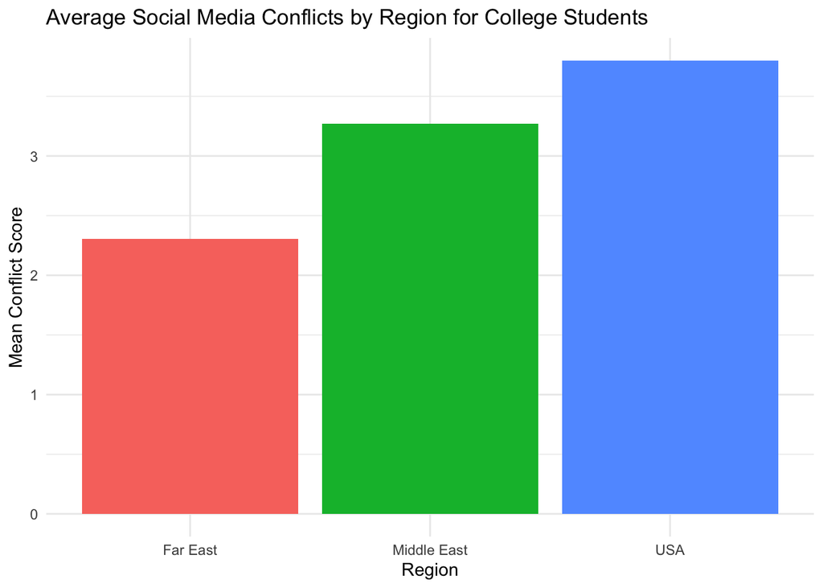

## Discussion

Our research sought to observe possible correlations and patterns surrounding social media use among youth, looking at additional factors such as sleep, mental health, gender, platform use, social media addiction, geographical region, and conflicts on social media. In observing possible relationships between mental health and screen use, our findings showed a negative relationship with sleep duration acting as a partial mediator. The reduced direct effect when accounting for sleep suggests that part of the harm with higher screen time comes from a reduction in sleep, though the continued significance of screen use indicates that additional variables likely contribute to diminished mental health. The lack of an aforementioned “tipping point” further reinforces this pattern, instead revealing a more incremental decline. While this incremental pattern appeared for both men and women, the steeper decline among women at higher usage levels suggests that excessive exposure may present a disproportionate strain for female students.

Specific platform use added additional patterns. Although hypotheses regarding Meta-affiliated platforms received mixed levels of support, these findings highlight meaningful variability linked to platform prioritization. Users who primarily used WhatsApp consistently reported the lowest mental health scores, the highest proportion of lower than average mental health, and elevated levels of social media addiction. Instagram users also exhibited comparatively high rates of low mental health. In contrast, Facebook users did not follow this pattern, aligning more closely with respondents who fell above the average threshold for mental health. These differences indicate that the emotional or behavioral repercussions associated with social media use are not sharply uniform across platforms, but instead, each platform appears to cultivate different user experiences, potentially reflecting differences in platform norms and purposes. The strong association between platform use and mental health groupings, confirmed through chi-square analysis, further suggests that patterns in mental health status are in some part structured by users’ choice of platform.

Finally, our findings revealed that regional context meaningfully shapes the relationship between mental health and the frequency of conflicts over social media. While poorer mental health predicted higher levels of social media conflicts among students regardless of region, the strength of this relationship differed substantially across the three observed regions. Students in the Middle East showed the strongest association between mental distress and social media conflict, followed by those in the Far East, with students from the United States demonstrating the weakest relationship. These disparities suggest that the consequences of diminished well-being for digital interpersonal interactions and experiences may be intensified by certain sociocultural elements, where region-specific contexts may amplify the impact of observed strain. The consistent ordering of averages across regions supports the notion that the emotional context in which students engage online is deeply linked with broader regional differences.

Altogether, these results reveal a comprehensive perspective in which screen time, sleep, platform prioritization, and regional environment all shape the mental health landscape for today’s school-age youth. Rather than any single variable driving certain outcomes, patterns of digital use interact with behavioral habits and contextual factors to produce different mental health profiles and online experiences.

## References

Ahmed, Oli, Amy Dawel, Erin I Walsh, and Nicolas Cherbuin. 2025. “Longitudinal Associations Between Problematic Social Media Use and Mental Health: Mediating Role of Sleep.” *Addict. Behav.* 170 (108446): 108446.

Al-Krenawi, Alean, John R Graham, Eman A Al-Bedah, Hafni Mahmud Kadri, and Mahmud A Sehwail. 2009. “Cross-National Comparison of Middle Eastern University Students: Help-Seeking Behaviors, Attitudes Toward Helping Professionals, and Cultural Beliefs about Mental Health Problems.” *Community Ment. Health J.* 45 (1): 26–36.

Alonzo, Rea, Junayd Hussain, Saverio Stranges, and Kelly K. Anderson. 2021. “Interplay Between Social Media Use, Sleep Quality, and Mental Health in Youth: A Systematic Review.” *Sleep Medicine Reviews* 56: 101414. https://doi.org/https://doi.org/10.1016/j.smrv.2020.101414.

Alvarez de Mon, Miguel Angel, Almudena Sánchez-Villegas, Luis Gutiérrez-Rojas, and Miguel A Martinez-Gonzalez. 2024. “Screen Exposure, Mental Health and Emotional Well-Being in the Adolescent Population: Is It Time for Governments to Take Action?” 78 (12): 759–63. https://doi.org/10.1136/jech-2023-220577.

Aubry, Raphaël, Alain Quiamzade, and Laurenz L Meier. 2024. “Depressive Symptoms and Upward Social Comparisons During Instagram Use: A Vicious Circle.” *Pers. Individ. Dif.* 217 (112458): 112458.

Barthorpe, Amber, Lizzy Winstone, Becky Mars, and Paul Moran. 2020. “Is Social Media Screen Time Really Associated with Poor Adolescent Mental Health? A Time Use Diary Study.” *Journal of Affective Disorders* 274: 864–70.

Basterra-Gortari, Virginia, Mario Gil-Conesa, Carmen Sayón-Orea, Francisca Lahortiga-Ramos, Carmen De la Fuente-Arrillaga, Miguel A. Martínez-González, and Maira Bes-Rastrollo. 2024. “Daily Time Spent on Screens and Psychological Well-Being: Cross-Sectional Association Within the SUN Cohort.” *Preventive Medicine* 181: 107912. https://doi.org/https://doi.org/10.1016/j.ypmed.2024.107912.

Chan, Chung-hong, Thomas J. Leeper, Jason Becker, and David Schoch. 2023. *Rio: A Swiss-Army Knife for Data i/o*. https://CRAN.R-project.org/package=rio.

Côrte-Real, Beatriz, Catarina Cordeiro, Pedro Câmara Pestana, Inês Duarte E Silva, and Filipa Novais. 2023. “Addictive Potential of Social Media: A Cross Sectional Study in Portugal.” *Acta Med. Port.* 36 (3): 162–66.

Di Cara, Nina H, Lizzy Winstone, Luke Sloan, Oliver Sp Davis, and Claire Ma Haworth. 2022. “The Mental Health and Well-Being Profile of Young Adults Using Social Media.” *Npj Ment. Health Res.* 1 (1).

Dibben, Grace O, Anne Martin, Colin B Shore, Avril Johnstone, Christina McMellon, Victoria Palmer, Juliana Pugmire, et al. 2023. “Adolescents’ Interactive Electronic Device Use, Sleep and Mental Health: A Systematic Review of Prospective Studies.” *J. Sleep Res.* 32 (5): e13899.

Elbers, Benjamin. 2024. *Tidylog: Logging for ’Dplyr’ and ’Tidyr’ Functions*. https://CRAN.R-project.org/package=tidylog.

Engeln, Renee, Ryan Loach, Megan N Imundo, and Anne Zola. 2020. “Compared to Facebook, Instagram Use Causes More Appearance Comparison and Lower Body Satisfaction in College Women.” *Body Image* 34 (September): 38–45.

Firke, Sam. 2023. *Janitor: Simple Tools for Examining and Cleaning Dirty Data*. https://CRAN.R-project.org/package=janitor.

Hale, Lauren E. 2019. “30.1 Digital Media and Sleep Health Among Adolescents: Does Sleep Mediate the Association Between Screen Time and Depressive Symptoms?” *J. Am. Acad. Child Adolesc. Psychiatry* 58 (10): S344–45.

Kircaburun, Kagan, Saleem Alhabash, Şule Betül Tosuntaş, and Mark D Griffiths. 2020. “Uses and Gratifications of Problematic Social Media Use Among University Students: A Simultaneous Examination of the Big Five of Personality Traits, Social Media Platforms, and Social Media Use Motives.” *Int. J. Ment. Health Addict.* 18 (3): 525–47.

Kohler, Madison T, Imani N Turner, and Gregory D Webster. 2021. “Social Comparison and State–Trait Dynamics: Viewing Image-Conscious Instagram Accounts Affects College Students’ Mood and Anxiety.” *Psychol. Pop. Media* 10 (3): 340–49.

Lake, Morgan. 2011. “An Exploratory Study of Culture and Cyber Harassment.” *Int. J. Manag. Decis. Mak.* 11 (5/6): 387.

LeBourgeois, Monique K, Lauren Hale, Anne-Marie Chang, Lameese D Akacem, Hawley E Montgomery-Downs, and Orfeu M Buxton. 2017. “Digital Media and Sleep in Childhood and Adolescence.” *Pediatrics* 140 (Supplement_2): S92–96.

Marengo, Davide, Matteo Angelo Fabris, Claudio Longobardi, and Michele Settanni. 2022. “Smartphone and Social Media Use Contributed to Individual Tendencies Towards Social Media Addiction in Italian Adolescents During the COVID-19 Pandemic.” *Addict. Behav.* 126 (107204): 107204.

Merino, Mariana, José Francisco Tornero-Aguilera, Alejandro Rubio-Zarapuz, Carlota Valeria Villanueva-Tobaldo, and Vicente Javier Clemente-Suárez. 2025. “Impact of Social Media Platforms on Physical Characteristics and Psychological Profiles.” *Glob. J. Health Sci.* 17 (5): 1.

Montag, Christian, Elisa Wegmann, Lasse David Schmidt, Lena Klein, Dmitri Rozgonjuk, and Hans-Jürgen Rumpf. 2024. “Insights on Associations Between the Frequency of Use of Diverse Social Media Products and Social Networks Use Disorder Tendencies from a German Speaking Sample.” *BMC Res. Notes* 17 (1): 189.

Müller, Kirill. 2020. *Here: A Simpler Way to Find Your Files*. https://CRAN.R-project.org/package=here.

Naslund, John A, Ameya Bondre, John Torous, and Kelly A Aschbrenner. 2020. “Social Media and Mental Health: Benefits, Risks, and Opportunities for Research and Practice.” *Journal of Technology in Behavioral Science* 5 (3): 245–57.

Neophytou, Eliana, Laurie A Manwell, and Roelof Eikelboom. 2021. “Effects of Excessive Screen Time on Neurodevelopment, Learning, Memory, Mental Health, and Neurodegeneration: A Scoping Review.” *International Journal of Mental Health and Addiction* 19 (3): 724–44.

Pagano, Maria, Valeria Bacaro, and Elisabetta Crocetti. 2023. “‘Using Digital Media or Sleeping … That Is the Question.’ A Meta-Analysis on Digital Media Use and Unhealthy Sleep in Adolescence.” *Comput. Human Behav.* 146 (107813): 107813.

Pendse, Sachin R, Kate Niederhoffer, and Amit Sharma. 2019. “Cross-Cultural Differences in the Use of Online Mental Health Support Forums.” *Proc. ACM Hum. Comput. Interact.* 3 (CSCW): 1–29.

Pontes, Halley M. 2021. “Critically Appraising the Pitfalls of Screen Time Effects Research.” *Australian & New Zealand Journal of Psychiatry* 55 (9): 922–22. https://doi.org/10.1177/0004867420963736.

Primack, Brian A, Ariel Shensa, César G Escobar-Viera, Erica L Barrett, Jaime E Sidani, Jason B Colditz, and A Everette James. 2017. “Use of Multiple Social Media Platforms and Symptoms of Depression and Anxiety: A Nationally-Representative Study Among U.S. Young Adults.” *Comput. Human Behav.* 69 (April): 1–9.

Przybylski, Andrew K, and Netta Weinstein. 2017. “A Large-Scale Test of the Goldilocks Hypothesis.” *Psychol. Sci.* 28 (2): 204–15.

Shadzi, Mohammad Reza, Alireza Salehi, and Hossein Molavi Vardanjani. 2020. “Problematic Internet Use, Mental Health, and Sleep Quality Among Medical Students: A Path-Analytic Model.” *Indian J. Psychol. Med.* 42 (2): 128–35.

Shamim, Adil. 2025. “Students’ Social Media Addiction.” Kaggle. https://www.kaggle.com/datasets/adilshamim8/social-media-addiction-vs-relationships.

Smith, Peter K, Anke Görzig, and Susanne Robinson. 2019. “Cyberbullying in Schools.” In *Cyberbullying in Schools, Workplaces, and Romantic Relationships*, 49–68. Routledge.

Stiglic, Neza, and Russell M Viner. 2019. “Effects of Screentime on the Health and Well-Being of Children and Adolescents: A Systematic Review of Reviews” 9 (1). https://doi.org/10.1136/bmjopen-2018-023191.

Twenge, Jean M., and W. Keith Campbell. 2018. “Associations Between Screen Time and Lower Psychological Well-Being Among Children and Adolescents: Evidence from a Population-Based Study.” *Preventive Medicine Reports* 12: 271–83. https://doi.org/https://doi.org/10.1016/j.pmedr.2018.10.003.

Verduyn, Philippe, Nino Gugushvili, Karlijn Massar, Karin Täht, and Ethan Kross. 2020. “Social Comparison on Social Networking Sites.” *Curr. Opin. Psychol.* 36 (December): 32–37.

Waring, Elin, Michael Quinn, Amelia McNamara, Eduardo Arino de la Rubia, Hao Zhu, and Shannon Ellis. 2022. *Skimr: Compact and Flexible Summaries of Data*. https://CRAN.R-project.org/package=skimr.

Wickham, Hadley, Mara Averick, Jennifer Bryan, Winston Chang, Lucy D’Agostino McGowan, Romain François, Garrett Grolemund, et al. 2019. “Welcome to the tidyverse.” *Journal of Open Source Software* 4 (43): 1686. https://doi.org/10.21105/joss.01686.

Xie, Yihui. 2014. “Knitr: A Comprehensive Tool for Reproducible Research in R.” In *Implementing Reproducible Research*, edited by Victoria Stodden, Friedrich Leisch, and Roger D. Peng. Chapman; Hall/CRC. http://www.crcpress.com/product/isbn/9781466561595.

———. 2015. *Dynamic Documents with R and Knitr*. 2nd ed. Boca Raton, Florida: Chapman; Hall/CRC. https://yihui.org/knitr/.

———. 2023. *Knitr: A General-Purpose Package for Dynamic Report Generation in r*. https://yihui.org/knitr/.

Zhu, Hao. 2024. *kableExtra: Construct Complex Table with ’Kable’ and Pipe Syntax*. https://CRAN.R-project.org/package=kableExtra.